# Seattle Crime Analysis by Dates and Times

John Fitzpatrick

January 10, 2016

# Analysis of Crime frequency in Seattle

This analysis will attempt to highlight the frequency of crimes in the summer of 2014 for the city of Seattle. The analysis will look at crime counts by

1. Date
2. Day of the week
3. Hour of the Day

It’s hoped that this analysis would aid police planners in allocating manpower and other resources to the times when crimes are most frequently committed

### Crimes by Date

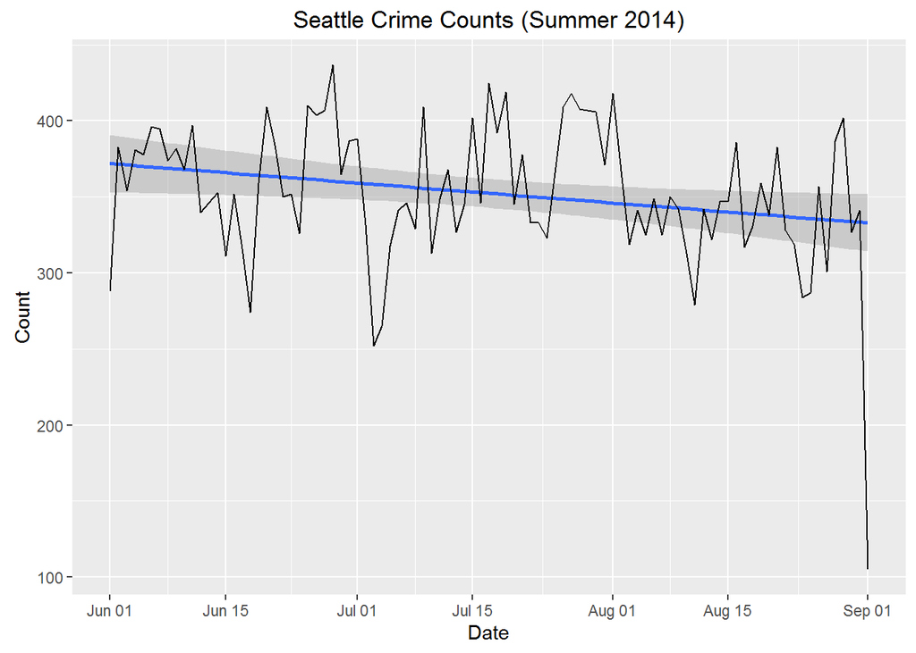

We can see that there’s a lot of variability in the crime counts from day to day. But that there’s a general downward trend from the beginning of the summer to the end of the summer. Without further information I believe the drop in crimes on the last day is likely due to some type of reporting anomaly since it’s over twice as low as the next low crime day

```
## Source: local data frame [5 x 2]
##
##   Occurred.Date count
##          (date) (int)
## 1    2014-09-01   105
## 2    2014-07-03   252
## 3    2014-07-04   265
## 4    2014-06-18   274
## 5    2014-08-11   279
```

### Crimes by Day of Week

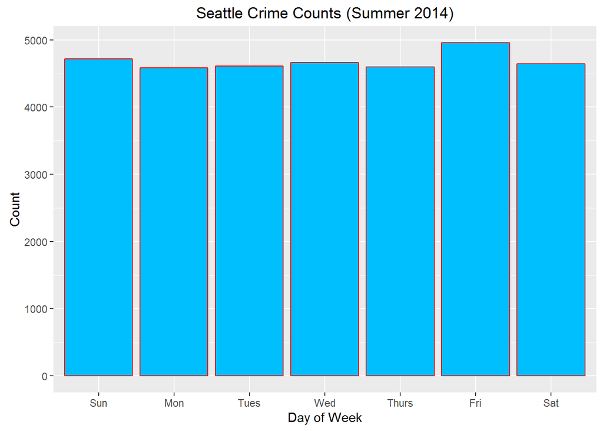

There seems to be a noticeable increase in crime on Fridays compared to the other days in the week

### Crimes by Hour of the Day

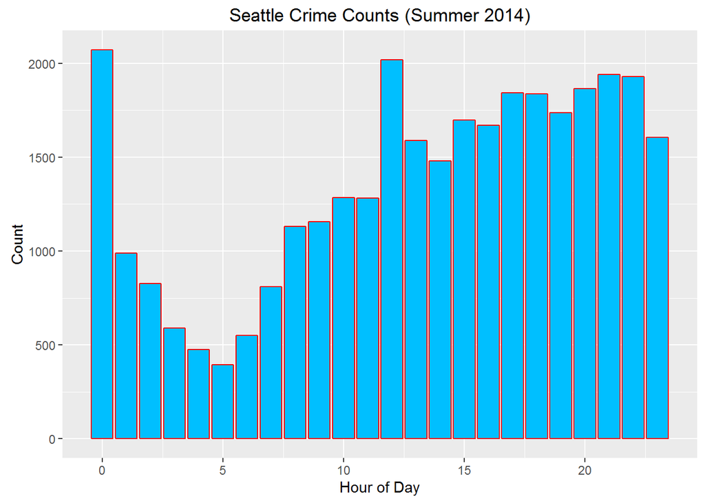

Crime is highest between midnight and 1AM and then drops sharply during the wee hours of the morning. It then starts picking up again around 6AM and increases steadily with a peak around noon. It remains high for the rest of the day until the new after-midnight peak is reached.